# Beyond ‘Adjusting for Race’: Data Equity in Clinical Research

HIP 523: Data Science for Clinical & Translational Research

Jessica Minnier, PhD

Co-Director, Cancer Data Science Shared Resource (CDSSR), Knight Cancer Institute

Associate Professor of Biostatistics, OHSU-PSU School of Public Health

November 11, 2026

## Learning Objectives

By the end of this session, you'll be able to:

- Describe what data equity means for EHR and real-world data
- Recognize common sources of bias in how race, sex, gender, and SDOH are recorded
- Decide what to adjust for when the question is about a disparity
- Read "we adjusted for race" with a critical eye

## Where This Fits in HIP 523

Earlier in this course:

- EHR data and data quality: missing and miscoded data aren't spread evenly across patients
- TriNetX & Cosmos: race, ethnicity, and SDOH come in categories someone else picked
- The research data lifecycle: equity questions come up at every step, from design to sharing
- Algorithmic fairness: prediction models can work worse for some groups

Today I'll focus on the regression side: how we use models to **measure and explain disparities**, and how the choice of what to adjust for changes the answer.

# What is Data Equity?

[figure not shown]

UMD Library Guide

## What is Data Equity?

- Paying attention to power, bias, and discrimination in how data are collected, analyzed, interpreted, and used
- Making sure research benefits everyone, especially groups that have been left out
- Data aren't neutral. They reflect the systems and biases they came from
- Communities and patients have a say in the research, and ideally ownership of their own data (data sovereignty; see the [CARE Principles](https://doi.org/10.5334/dsj-2020-043))
- The goal: results that are fair, accurate, and useful for reducing disparities

Sources: [Community Commons](https://www.communitycommons.org/collections/An-Introduction-to-Data-Equity), [CDC Foundation](https://www.cdcfoundation.org/data-equity-principles?inline), [UMD Library Guide](https://lib.guides.umd.edu/ResearchEquity/DataEquity), [Data.org](https://data.org/resources/what-is-data-equity-and-why-does-it-matter/), [Carroll et al. (2020)](https://doi.org/10.5334/dsj-2020-043)

## Data Equity Principles

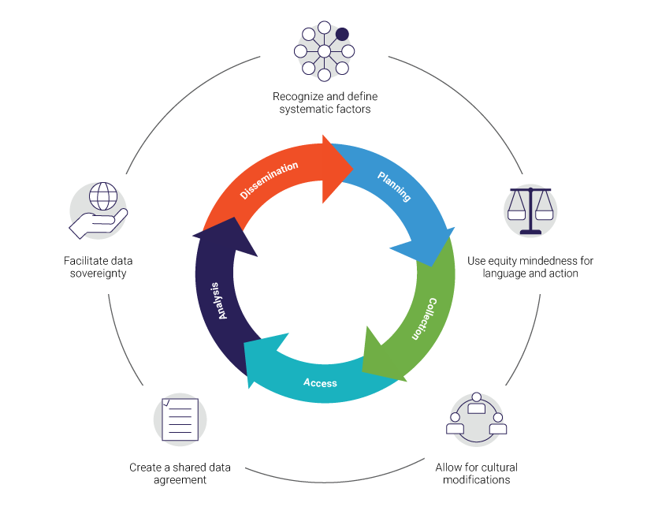

CDC Foundation Data Equity Principles

# What is Equity-minded Research?

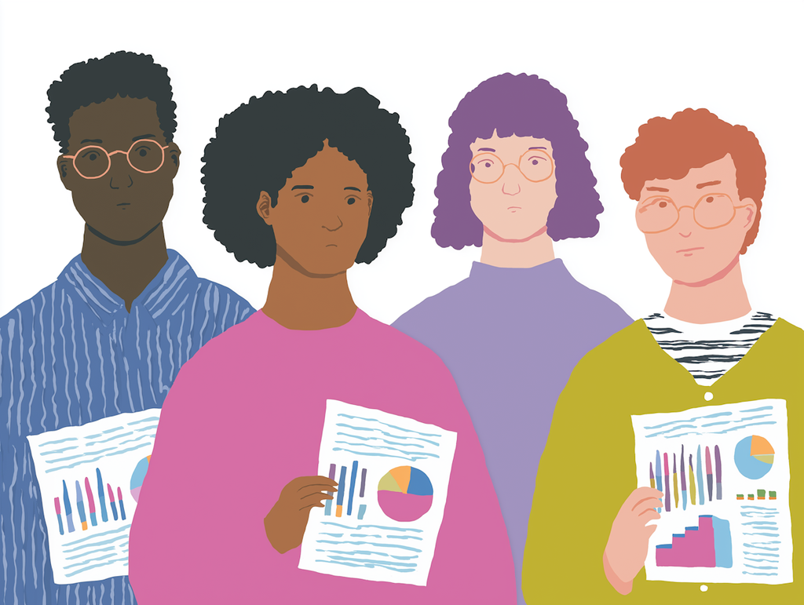

[Lummi.ai](https://www.lummi.ai/illustration/data-presentation-team-x1xh7)

## Equity-minded Research

- Name the systemic factors that could shape your outcome: access, insurance, neighborhood, discrimination
- Collect data inclusively: interpreters, self-reported race and gender, more than two categories
- [Sample](https://www.nature.com/articles/s41591-023-02665-1) so the groups you care about are represented
- Reflect on your own position and assumptions (positionality)
- Interpret in context: a difference by race is a reason to ask why
- Report results by subgroup, and say what you couldn't measure

Sources: [Venkateswaran et al. (2023)](https://doi.org/10.3768/rtipress.2023.op.0085.2301); [Retzer et al. (2023)](https://doi.org/10.1038/s41591-023-02665-1)

## Common Data Equity Challenges in EHR Data

- Selection bias: the EHR only sees patients who come in
  - Ex: rural patients who come to an academic center only for specialty care
- Missing data isn't random
  - Ex: race recorded as "Unknown" or "Declined"; interpreter need not documented
- Where did the value come from?
  - Ex: race self-reported by the patient vs. entered by a registrar

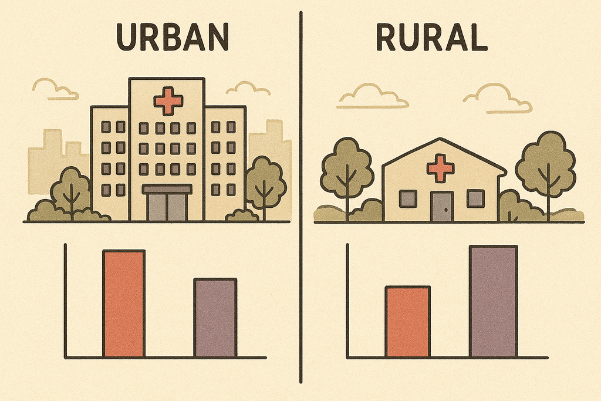

## Aggregation and Small Groups

- Collapsing groups can hide disparities
  - Ex: Asian American subgroups ([Haelle 2022](https://healthjournalism.org/blog/2022/08/how-improper-aggregation-of-racial-ethnic-groups-in-research-can-mask-health-disparities/))
  - Ex: asthma prevalence differs for US-born and non-US-born Latinos [Marino et al. (2023)](https://doi.org/10.1111/1475-6773.14154)
- Small groups: report them with confidence intervals instead of collapsing by default
  - Multilevel models can help [Evans et al. (2018)](https://doi.org/10.1016/j.socscimed.2017.11.011)

## Missing Context and History

- Lack of contextual variables
  - Ex: post-op complications with patient factors but no hospital factors, like nurse staffing
  - Ex: asthma prevalence without air quality or housing conditions
- History of unethical research and misuse of demographic data
  - Harmful research on Black Americans has led to justified mistrust and underrepresentation in studies
  - The Tuskegee syphilis study is one example [Katz et al. (2006)](https://doi.org/10.1353/hpu.2006.0126)

# Sex and Gender Considerations

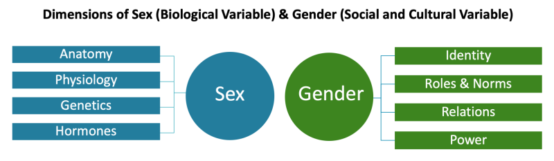

NIH Sex and Gender

Source: [NIH Office of Research on Women's Health](https://orwh.od.nih.gov/sex-as-biological-variable)

## Sex and Gender in Research

- Sex (biological) and gender (social) are different variables
  - EHR "sex" fields often mix sex assigned at birth, legal sex, and gender identity
- Don't assume a binary; document missing data
- NIH policy on [Sex as a Biological Variable (SABV, 2016)](https://orwh.od.nih.gov/sex-gender/orwh-mission-area-sex-gender-in-research/nih-policy-on-sex-as-biological-variable):
  - adequate sample sizes for all sexes
  - test for sex-specific effects
  - report sex-disaggregated results
- Common pitfalls: too few women; transgender and intersex people left out; interactions ignored

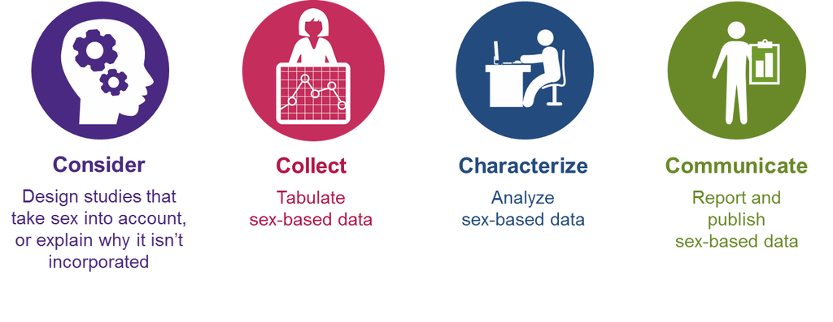

NIH 4 Cs of Studying SABV

# Race and Ethnicity in Research

> Race is a social construct, commonly used in epidemiologic research to adjust for confounding. However, adjustment of race may mask racial disparities, thereby perpetuating structural racism.

"We adjusted for race": now what? A systematic review... [Swilley-Martinez et al. (2023)](https://doi.org/10.1093/epirev/mxad010)

## Race and Ethnicity: Critical Considerations

- Race is a social construct, not biological
- There's more variation within groups than between them
- Racial categories have a history, and they've changed over time
- Ask what the race variable stands for in your study: exposure to racism, culture, ancestry, or something else
- Race intersects with other variables (sex, income, language)

## Race and Ethnicity: Recommendations

- Use clearly defined categories; don't collapse groups with different outcomes
  - Avoid "Other"; describe what a collapsed category contains
  - Include ethnicity and ancestry information
- Document how race and ethnicity were collected and classified
- The 2024 federal standard ([OMB SPD 15](https://www.federalregister.gov/documents/2024/03/29/2024-06469/revisions-to-ombs-statistical-policy-directive-no-15-standards-for-maintaining-collecting-and-presenting)) combines race and ethnicity into one question and adds Middle Eastern or North African. EHR categories will change
- If race is in the model, check whether effects differ by race (effect modification)
- Acknowledge limitations

[Urban Institute: Using Race and Ethnicity Data to Advance Health Equity](https://www.urban.org/research/publication/using-race-and-ethnicity-data-advance-health-equity); [Swilley-Martinez et al. (2023)](https://doi.org/10.1093/epirev/mxad010)

## Race in Clinical Algorithms and Measurement

Bias can be built into EHR values before any analysis happens.

- Kidney function: a race term in eGFR made Black patients' kidneys look healthier, delaying referral and transplant listing. Removed in 2021 [Inker et al. (2021)](https://doi.org/10.1056/NEJMoa2102953)
- Pulse oximetry reads high in darker skin; hidden low oxygen was missed about 3 times as often in Black patients [Sjoding et al. (2020)](https://doi.org/10.1056/NEJMc2029240)
- Race correction shows up in calculators across many specialties [Vyas et al. (2020)](https://doi.org/10.1056/NEJMms2004740)
- Models built on these values inherit the bias (app tab 5)

# Social Determinants of Health (SDOH)

[figure not shown]

[US Dept of Health & Human Services: Healthy People 2030](https://odphp.health.gov/healthypeople/priority-areas/social-determinants-health)

## SDOH: Data Considerations

- Equitable sampling; granular, standardized definitions
- Often missing in the EHR
  - ICD-10 Z-codes for social needs (e.g., housing instability) are often left blank
- Area-level measures linked by address
  - Area Deprivation Index (ADI), Social Vulnerability Index (SVI)
  - They describe the neighborhood, not the person (ecological fallacy)

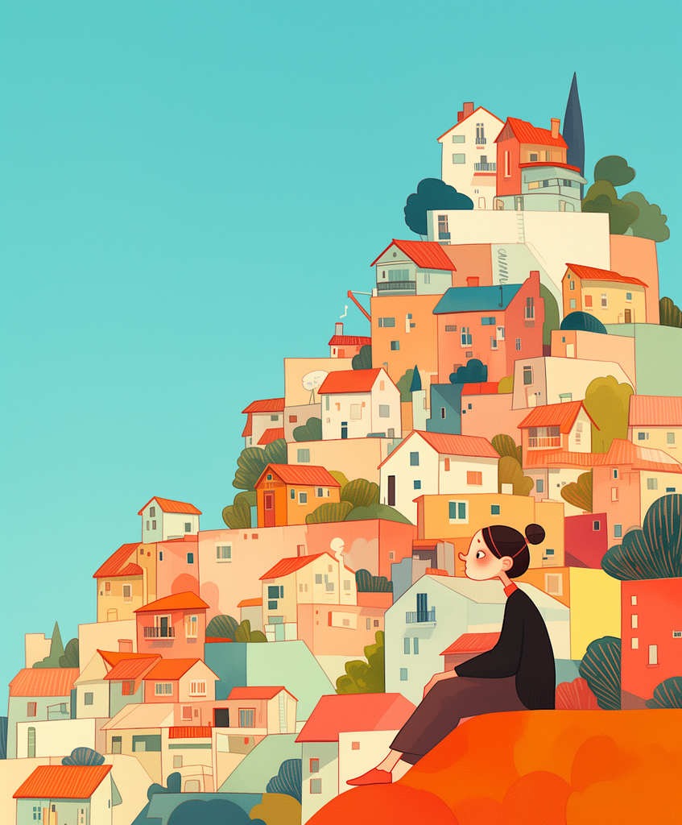

## SDOH: Analysis Considerations

- Including SDOH variables in models can be complex
- For each one, ask: is it a confounder, a mediator, or an effect modifier?
- SDOH variables are correlated with each other (income, education, neighborhood)
- Address missing data

[Braveman (2023)](https://doi.org/10.1093/oso/9780190624118.001.0001)

## Statistical Analysis: What Does "Adjusted For" Mean?

What does controlling for race (or sex, or gender, or SDOH) mean?

- Adjustment, matching, and stratification estimate the effect within groups, then combine them
  - Ex: compare statin rates by insurance within each age group, then average
- The combined effect is weighted toward the larger groups
- Adjusting for race compares people within race groups. It does not remove the effects of racism, and it can hide them
- Effect modification: let the effect differ by group instead of averaging

[Swilley-Martinez et al. (2023)](https://doi.org/10.1093/epirev/mxad010)

## Confounder or Mediator?

**Confounder:** comes before the attribute and affects the outcome. Usually adjust for it.

Age → Insurance (Medicaid vs. private)

Age → Statin prescribed

**Mediator (a post-attribute variable):** is affected by the attribute and is on the path to the outcome. Adjusting for it removes that path from the estimate.

Race → Triage acuity → Opioid analgesia

The attribute is the characteristic we're asking about disparities by (race, insurance, language).

## Modeling Decisions

**Bivariate Model: Y~X**

- Use when asking "Does a demographic group receive access at different rates?"
- This is the **total disparity**

**Multiple Regression Y~X+Z**

- Use when asking "Do similarly situated individuals access benefits at the same rate?"
- This is the **residual disparity** after adjusting for Z. Which Z's belong in the model (confounders, not mediators) depends on the question

[Duan et al. (2008)](https://doi.org/10.1002/sim.3283); [Jackson and VanderWeele (2018)](https://doi.org/10.1097/EDE.0000000000000901)

## Characterizing Confounding

When race is the confounder, what kind of confounding is it?

1. **Discriminatory:** effects on the exposure and outcome are due to individual or systemic discrimination
2. **Sociocultural:** effects are due to personal or cultural practices
3. **Biological:** effects are directly due to biological mechanisms

The type changes how to interpret an adjusted estimate [Swilley-Martinez et al. (2023)](https://doi.org/10.1093/epirev/mxad010)

# Modeling Examples

[Interactive App: minnier.shinyapps.io/equity_regression](https://minnier.shinyapps.io/equity_regression/)

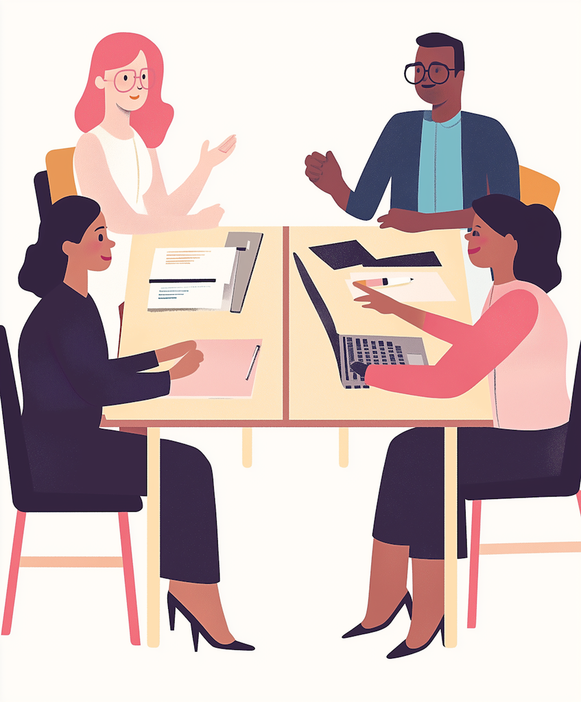

## Example 1: Opioid Analgesia in the ED

- **Research Question:** Among ED visits for a long-bone fracture, are Black patients less likely to receive opioid analgesia?
  - Real studies find they are: pooled OR 0.60 for analgesia, Black vs. White patients [Lee et al. (2019)](https://doi.org/10.1016/j.ajem.2019.06.014)
- **Outcome (Y):** Received opioid analgesia (yes/no)
- **Attribute of Interest (X):** Patient race (Black vs. White)

*Bivariate Regression Model:*

`glm(analgesia ~ race, binomial, data = ed)`

**Interpretation:** "On average, are Black patients less likely to get opioid analgesia than White patients?"

*Multiple Regression Model:*

`glm(analgesia ~ race + triage_acuity, binomial, data = ed)`

**Interpretation:** "Among patients with the same triage acuity, is there still a difference?" (Triage acuity = Emergency Severity Index, ESI, 1 = most urgent)

## Discussion: Post-attribute Bias

Adjusting for a step where bias happens can hide the bias.

- Triage acuity is assigned by a person, and Black patients are more often under-triaged [Schrader and Lewis (2013)](https://doi.org/10.1016/j.jemermed.2012.05.010); [Sax et al. (2023)](https://doi.org/10.1001/jamanetworkopen.2023.3404)
- If race affects triage, and triage affects treatment, adjusting for triage removes that part of the disparity
- The bivariate model may be more appropriate. Here the "race" effect could be the effect of systemic racism

**Post-attribute bias** occurs when we control for variables that may be affected by the attribute we're studying (a.k.a. post-treatment bias, intermediate variable bias, mediating variable bias)

## Example 2: Statin Prescribing

- **Research Question:** Among adults with diabetes in an EHR cohort, are patients with Medicaid less likely to be prescribed a statin?
- **Outcome:** Statin prescribed (yes/no)
- **Attribute of Interest:** Insurance type (Private vs. Medicaid)

*Bivariate Regression Model:*

`glm(statin ~ insurance, binomial, data = dm)`

**Interpretation:** "On average, are patients with Medicaid less likely to be prescribed a statin than patients with private insurance?"

*Multiple Regression Model:*

`glm(statin ~ insurance + age, binomial, data = dm)`

**Interpretation:** "Among patients of the same age, are Medicaid patients still less likely to be prescribed a statin?"

## Discussion: Omitted Variable Bias

Adjust for confounders. Age comes before insurance, so it belongs in the model.

- In our simulated cohort, Medicaid patients are younger, and statin recommendations depend on age
- Leaving age out makes the gap look bigger than it is
- Adjusting for age can still leave a real gap, and that's the part worth asking about
- Contrast with Example 1: age is a confounder (adjust); triage is a mediator (be careful)

## Example 3: Readmission After Heart Failure

- **Research Question:** Are patients with Limited English Proficiency (LEP) more likely to be readmitted within 30 days after a heart failure hospitalization?
- **Outcome:** Readmitted within 30 days (Yes/No)
- **Attribute of Interest:** LEP status (needs interpreter vs. English proficient)

*Bivariate Regression Model:*

`glm(readmit_30d ~ lep_status, binomial, data = hf)`

**Interpretation:** "Do patients with LEP have a higher 30-day readmission rate?"

*Multiple Regression Model:*

`glm(readmit_30d ~ lep_status + followup_7d, binomial, data = hf)`

**Interpretation:** "If LEP and English-proficient patients made it to follow-up at the same rate, would readmission still differ?"

## Discussion: Disparities vs. Mechanisms

Same diagram as Example 1, different question.

- Follow-up is a mediator, like triage acuity in Example 1
- "Is there a disparity?" Use the unadjusted model. LEP patients are readmitted more often
- "Where does it come from?" Adjust for follow-up. In our simulated data the gap mostly disappears, so follow-up is where to intervene: interpreters at discharge, instructions in the patient's language

|  | Mediator | Question | Model |
| --- | --- | --- | --- |
| Ex 1 | Triage (a biased step) | Is treatment fair overall? | Unadjusted |
| Ex 3 | Follow-up (a fixable step) | Where does the gap come from? | Both, labeled |

## Optional Example 4: Effect Modification

- **Research Question:** Does a remote blood pressure monitoring program work as well for patients in high-deprivation neighborhoods?
- **Outcome:** Change in systolic BP at 6 months (mmHg)
- **Exposure:** Remote monitoring vs. usual care
- **Effect modifier:** Neighborhood Area Deprivation Index (ADI), high vs. low

*Main Effects Model:*

`lm(sbp_change ~ program + adi, data = bp)`

**Interpretation:** "On average, how much does the program lower BP?"

*Interaction Model:*

`lm(sbp_change ~ program * adi, data = bp)`

**Interpretation:** "Does the program lower BP by the same amount in high- and low-ADI neighborhoods?"

One average effect can hide a group the program doesn't help. App, tab 4.

## Using Regression to Detect Discrimination

- Cannot definitively prove discrimination
- Cannot definitively prove lack of discrimination
- Unmeasured variables may explain disparities
- Need robust research design for causal claims
- Report absolute differences (risk differences) along with odds ratios
- Check whether effects differ by group (effect modification, app tab 4)

## Best Practices for Reporting

- Sex and Gender Equity in Research (SAGER) Guidelines [Heidari et al. (2016)](https://doi.org/10.1186/s41073-016-0007-6)
- Race and ethnicity guidelines are often journal or study design specific [Flanagin et al. (2021)](https://doi.org/10.1001/jama.2021.13304)

### Equity extensions of reporting guidelines

- [STROBE-Equity (2025)](https://doi.org/10.1001/jamanetworkopen.2025.32512) for observational studies [Dewidar et al. (2025)](https://doi.org/10.1001/jamanetworkopen.2025.32512)
- [CONSORT-Equity (2017)](https://www.equator-network.org/reporting-guidelines/consort-equity/) for trials
- [PRISMA-Equity (2012)](https://www.prisma-statement.org/equity) for systematic reviews

## Perspective

[figure not shown]

> Data and data projects can only be made more equitable if work teams are diverse, reflect a variety of experiences, and trained to foreground empathy and equity in their work.

[Urban Institute's Do No Harm Guide: Additional Perspectives on Data Equity](https://www.urban.org/research/publication/do-no-harm-guide-additional-perspectives-data-equity)

## Optional: Discussion Questions

If we have time, pick one and put your thoughts in the chat. Otherwise, take them with you.

1. Think of EHR or real-world data you've used or seen. How were race, ethnicity, sex/gender, or SDOH recorded? What was missing, and who was it missing for?
2. You read: "After adjusting for race, we found no significant difference in 30-day mortality." What are we really adjusting for when we put race in the model? What could this be hiding?
3. How might your own background and position (clinician, researcher, trainee) shape the questions you ask or the variables you collect when studying health disparities?

## Thank you!

### Contact info:

- Jessica Minnier: *minnier@ohsu.edu*

### This talk info:

- Slides: bit.ly/hip26_data_eq
- Interactive app: [minnier.shinyapps.io/equity_regression](https://minnier.shinyapps.io/equity_regression/)
- Code for these slides is on GitHub, with links to other talks and course materials: jminnier/talks_etc
- Uncited art from [lummi.ai](https://www.lummi.ai/s/illustration/)

## References

Braveman, P. (2023). *The social determinants of health and health disparities*. Oxford University Press. DOI: [10.1093/oso/9780190624118.001.0001](https://doi.org/10.1093%2Foso%2F9780190624118.001.0001).

Carroll, S. R., I. Garba, O. L. Figueroa-Rodríguez, et al. (2020). "The CARE Principles for Indigenous Data Governance". In: *Data Science Journal* 19.1, p. 43. DOI: [10.5334/dsj-2020-043](https://doi.org/10.5334%2Fdsj-2020-043).

Dewidar, O., L. Shamseer, G. J. Melendez-Torres, et al. (2025). "Improving the reporting on health equity in observational research (STROBE-Equity): extension checklist and elaboration". In: *JAMA Network Open* 8.9, p. e2532512. DOI: [10.1001/jamanetworkopen.2025.32512](https://doi.org/10.1001%2Fjamanetworkopen.2025.32512).

Duan, N., X. Meng, J. Y. Lin, et al. (2008). "Disparities in defining disparities: statistical conceptual frameworks". In: *Statistics in Medicine* 27.20, pp. 3941-3956. DOI: [10.1002/sim.3283](https://doi.org/10.1002%2Fsim.3283).

Evans, C. R., D. R. Williams, J. Onnela, et al. (2018). "A multilevel approach to modeling health inequalities at the intersection of multiple social identities". In: *Social Science & Medicine* 203, pp. 64-73. DOI: [10.1016/j.socscimed.2017.11.011](https://doi.org/10.1016%2Fj.socscimed.2017.11.011).

Flanagin, A., T. Frey, S. L. Christiansen, et al. (2021). "Updated guidance on the reporting of race and ethnicity in medical and science journals". In: *Jama* 326.7, pp. 621-627. DOI: [10.1001/jama.2021.13304](https://doi.org/10.1001%2Fjama.2021.13304).

Heidari, S., T. F. Babor, P. De Castro, et al. (2016). "Sex and gender equity in research: rationale for the SAGER guidelines and recommended use". In: *Research integrity and peer review* 1, pp. 1-9. DOI: [10.1186/s41073-016-0007-6](https://doi.org/10.1186%2Fs41073-016-0007-6).

Inker, L. A., N. D. Eneanya, J. Coresh, et al. (2021). "New creatinine- and cystatin C-based equations to estimate GFR without race". In: *New England Journal of Medicine* 385.19, pp. 1737-1749. DOI: [10.1056/NEJMoa2102953](https://doi.org/10.1056%2FNEJMoa2102953).

Jackson, J. W. and T. J. VanderWeele (2018). "Decomposition analysis to identify intervention targets for reducing disparities". In: *Epidemiology* 29.6, pp. 825-835. DOI: [10.1097/EDE.0000000000000901](https://doi.org/10.1097%2FEDE.0000000000000901).

Katz, R. V., S. S. Kegeles, N. R. Kressin, et al. (2006). "The Tuskegee Legacy Project: willingness of minorities to participate in biomedical research". In: *Journal of health care for the poor and underserved* 17.4, pp. 698-715. DOI: [10.1353/hpu.2006.0126](https://doi.org/10.1353%2Fhpu.2006.0126).

Lee, P., M. Le Saux, R. Siegel, et al. (2019). "Racial and ethnic disparities in the management of acute pain in US emergency departments: meta-analysis and systematic review". In: *The American Journal of Emergency Medicine* 37.9, pp. 1770-1777. DOI: [10.1016/j.ajem.2019.06.014](https://doi.org/10.1016%2Fj.ajem.2019.06.014).

Marino, M., K. Fankhauser, J. Minnier, et al. (2023). "Disaggregating Latino nativity in equity research using electronic health records". In: *Health Services Research* 58.5, pp. 1119-1130. DOI: [10.1111/1475-6773.14154](https://doi.org/10.1111%2F1475-6773.14154).

Retzer, A., B. Ciytak, F. Khatsuria, et al. (2023). "A toolkit for capturing a representative and equitable sample in health research". In: *Nature Medicine* 29.12, pp. 3259-3267. DOI: [10.1038/s41591-023-02665-1](https://doi.org/10.1038%2Fs41591-023-02665-1).

Sax, D. R., E. M. Warton, D. G. Mark, et al. (2023). "Evaluation of the Emergency Severity Index in US emergency departments for the rate of mistriage". In: *JAMA Network Open* 6.3, p. e233404. DOI: [10.1001/jamanetworkopen.2023.3404](https://doi.org/10.1001%2Fjamanetworkopen.2023.3404).

Schrader, C. D. and L. M. Lewis (2013). "Racial disparity in emergency department triage". In: *The Journal of Emergency Medicine* 44.2, pp. 511-518. DOI: [10.1016/j.jemermed.2012.05.010](https://doi.org/10.1016%2Fj.jemermed.2012.05.010).

Sjoding, M. W., R. P. Dickson, T. J. Iwashyna, et al. (2020). "Racial bias in pulse oximetry measurement". In: *New England Journal of Medicine* 383.25, pp. 2477-2478. DOI: [10.1056/NEJMc2029240](https://doi.org/10.1056%2FNEJMc2029240).

Swilley-Martinez, M. E., S. A. Coles, V. E. Miller, et al. (2023). "“We adjusted for race”: now what? A systematic review of utilization and reporting of race in American Journal of Epidemiology and Epidemiology, 2020-2021". In: *Epidemiologic reviews* 45.1, pp. 15-31. DOI: [10.1093/epirev/mxad010](https://doi.org/10.1093%2Fepirev%2Fmxad010).

Venkateswaran, N., J. Feldman, S. Hawkins, et al. (2023). "Bringing an equity-centered framework to research: Transforming the researcher, research content, and practice of research".

DOI: [10.3768/rtipress.2023.op.0085.2301](https://doi.org/10.3768%2Frtipress.2023.op.0085.2301).

Vyas, D. A., L. G. Eisenstein, and D. S. Jones (2020). "Hidden in plain sight: reconsidering the use of race correction in clinical algorithms". In: *New England Journal of Medicine* 383.9, pp. 874-882. DOI: [10.1056/NEJMms2004740](https://doi.org/10.1056%2FNEJMms2004740).